# Functions Lab - Key

# Part 1

Load the `tidyverse` package.

```r
library(tidyverse)
```

### 1.1

Create a function that:

- Takes one argument, a vector.
- Returns the sum of the vector and then squares the result.
- Call it “sum_squared”.
- Test your function on the vector `c(2,7,21,30,90)` - you should get the answer 22500.
- Format is `NEW_FUNCTION <- function(x, y) x + y`

```r
nums <- c(2, 7, 21, 30, 90)

sum_squared <- function(x) sum(x)^2
sum_squared(x = nums)
```

```
## [1] 22500
```

```r
sum_squared <- function(x) {
  out <- sum(x)^2
  return(out)
}
sum_squared(x = nums)
```

```
## [1] 22500
```

### 1.2

Create a function that:

- takes two arguments, (1) a vector and (2) a numeric value.
- This function tests whether the number (2) is contained within the vector (1). **Hint**: use `%in%`.
- Call it `has_n`.
- Test your function on the vector `c(2,7,21,30,90)` and number `21` - you should get the answer TRUE.

```r
nums <- c(2, 7, 21, 30, 90)
a_num <- 21

has_n <- function(x, n) n %in% x
has_n(x = nums, n = a_num)
```

```
## [1] TRUE
```

### 1.3

Amend the function `has_n` from question 1.2 so that it takes a default value of `21` for the numeric argument.

```r
nums <- c(2, 7, 21, 30, 90)
a_num <- 21

has_n <- function(x, n = 21) n %in% x
has_n(x = nums)
```

```
## [1] TRUE
```

### P.1

Create a function for the CalEnviroScreen Data.

- Read in (https://daseh.org/data/CalEnviroScreen_data.csv)
- The function takes an argument for a column name. (use `{{col_name}}`)
- The function creates a ggplot with `{{col_name}}` on the x-axis and `Poverty` on the y-axis.
- Use `geom_point()`
- Test the function using the `Lead` column and `HousingBurden` columns, or other columns of your choice.

```r
ces <- read_csv("https://daseh.org/data/CalEnviroScreen_data.csv")
```

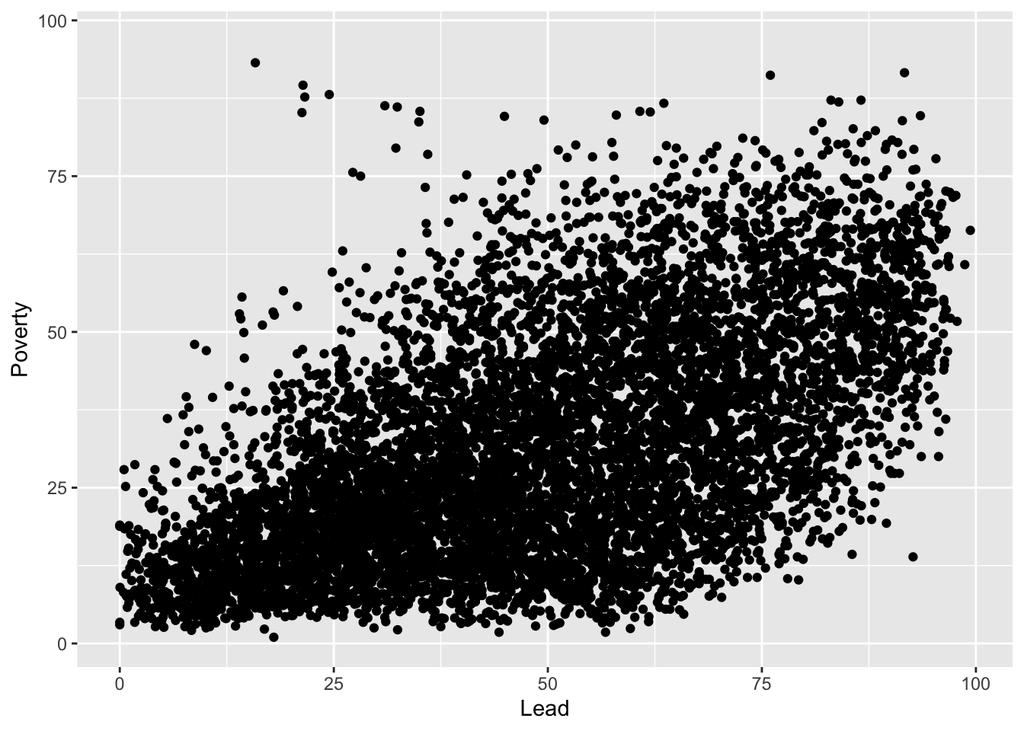

```r
plot_ces <- function(col_name){
  ggplot(data = ces, aes(x = {{col_name}}, y = Poverty)) +
    geom_point()
}

plot_ces(Lead)
```

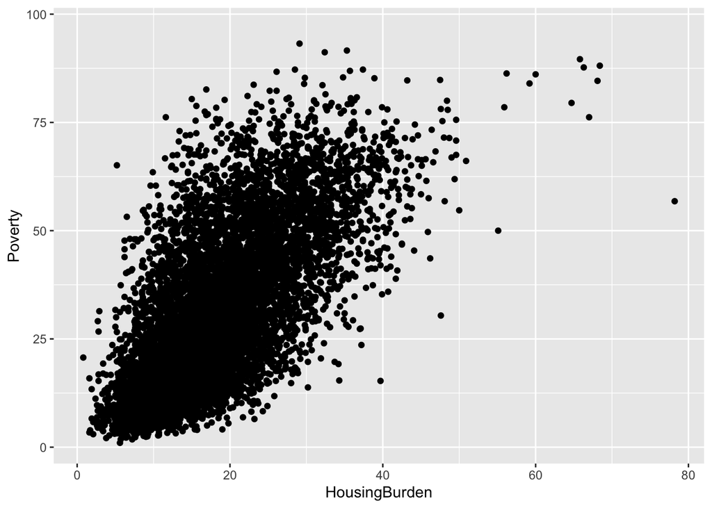

```r
plot_ces(HousingBurden)
```

# Part 2

### 2.1

Read in the CalEnviroScreen from https://daseh.org/data/CalEnviroScreen_data.csv. Assign the data the name “ces”.

```r
ces <- read_csv("https://daseh.org/data/CalEnviroScreen_data.csv")
# If downloaded
# ces <- read_csv("CalEnviroScreen_data.csv")
```

### 2.2

We want to get some summary statistics on water contamination.

- Use `across` inside `summarize`.
- Choose columns about “water”. **Hint**: use `contains("water")` inside `across`.
- Use `mean` as the function inside of `across`.
- Remember that `NA` values can influence calculations.

```
# General format
data |>
  summarize(across(
    {vector or tidyselect},
    {some function}
  ))
```

```r
ces |>
  summarize(across(
    contains("water"),
    mean
  ))
```

```
## # A tibble: 1 × 6
##   DrinkingWater DrinkingWaterPctl GroundwaterThreats GroundwaterThreatsPctl
##           <dbl>             <dbl>              <dbl>                  <dbl>
## 1            NA                NA               16.7                   37.8
## # ℹ 2 more variables: ImpWaterBodies <dbl>, ImpWaterBodiesPctl <dbl>
```

```r
# Accounting for NA
ces |>
  summarize(across(
    contains("water"),
    function(x) mean(x, na.rm = T)
  ))
```

```
## # A tibble: 1 × 6
##   DrinkingWater DrinkingWaterPctl GroundwaterThreats GroundwaterThreatsPctl
##           <dbl>             <dbl>              <dbl>                  <dbl>
## 1          477.              50.4               16.7                   37.8
## # ℹ 2 more variables: ImpWaterBodies <dbl>, ImpWaterBodiesPctl <dbl>
```

### 2.3

Convert all columns that are percentiles into proportions.

- Use `across` and `mutate`
- Choose columns that contain “Pctl” in the name. **Hint**: use `contains("Pctl")` inside `across`.
- Use an anonymous function (“function on the fly”) to divide by 100 (`function(x) x / 100`).
- Check your work - It will also be easier if you `select(contains("Pctl"))`.

```
# General format
data |>
  mutate(across(
    {vector or tidyselect},
    {some function}
  ))
```

```r
ces |>
  mutate(across(
    contains("Pctl"),
    function(x) x / 100
  )) |>
  select(contains("Pctl"))
```

```
## # A tibble: 8,035 × 23
##    OzonePctl PM2.5.Pctl DieselPMPctl DrinkingWaterPctl LeadPctl PesticidesPctl
##        <dbl>      <dbl>        <dbl>             <dbl>    <dbl>          <dbl>
##  1    0.0312      0.363        0.348            0.0421   0.0774              0
##  2    0.0312      0.420        0.927            0.0421   0.682               0
##  3    0.0312      0.439        0.898            0.0421   0.642               0
##  4    0.0312      0.428        0.791            0.0421   0.671               0
##  5    0.0312      0.428        0.676            0.0421   0.680               0
##  6    0.0312      0.428        0.838            0.0421   0.697               0
##  7    0.0312      0.433        0.813            0.0421   0.769               0
##  8    0.0312      0.440        0.687            0.0421   0.732               0
##  9    0.0312      0.440        0.811            0.0421   0.867               0
## 10    0.0312      0.458        0.994            0.0421   0.885               0
## # ℹ 8,025 more rows
## # ℹ 17 more variables: ToxReleasePctl <dbl>, TrafficPctl <dbl>,
## #   CleanupSitesPctl <dbl>, GroundwaterThreatsPctl <dbl>, HazWastePctl <dbl>,
## #   ImpWaterBodiesPctl <dbl>, SolidWastePctl <dbl>, PollutionBurdenPctl <dbl>,
## #   AsthmaPctl <dbl>, LowBirthWeightPctl <dbl>,
## #   CardiovascularDiseasePctl <dbl>, PopCharPctl <dbl>, EducationPctl <dbl>,
## #   LinguisticIsolPctl <dbl>, PovertyPctl <dbl>, UnemploymentPctl <dbl>, …
```

# Practice on Your Own!

### P.2

Use `across` and `mutate` to convert all columns starting with the string “PM” into a binary variable: TRUE if the value is greater than 10 and FALSE if less than or equal to 10.

- **Hint**: use `starts_with()` to select the columns that start with “PM”.
- Use an anonymous function (“function on the fly”) to do a logical test if the value is greater than 10.
- A logical test with `mutate` (x > 10) will automatically fill a column with TRUE/FALSE.

```r
ces |>
  mutate(across(
    starts_with("PM"),
    function(x) x > 10
  )) |>
  glimpse() # add glimpse to view the changes
```

```
## Rows: 8,035
## Columns: 67
## $ CensusTract               <dbl> 6001400100, 6001400200, 6001400300, 60014004…
## $ CaliforniaCounty          <chr> "Alameda", "Alameda", "Alameda", "Alameda", …
## $ ZIP                       <dbl> 94704, 94618, 94618, 94609, 94609, 94609, 94…
## $ Longitude                 <dbl> -122.2319, -122.2496, -122.2544, -122.2575, …
## $ Latitude                  <dbl> 37.86759, 37.84817, 37.84060, 37.84821, 37.8…
## $ ApproxLocation            <chr> "Oakland", "Oakland", "Oakland", "Oakland", …
## $ CES4.0Score               <dbl> 4.85, 4.88, 11.20, 12.39, 16.73, 20.02, 36.7…
## $ CES4.0Percentile          <dbl> 2.80, 2.87, 15.94, 18.97, 29.74, 37.59, 70.1…
## $ CES4.0PercRange           <chr> "1-5% (lowest scores)", "1-5% (lowest scores…
## $ Ozone                     <dbl> 0.029, 0.029, 0.029, 0.029, 0.029, 0.029, 0.…
## $ OzonePctl                 <dbl> 3.12, 3.12, 3.12, 3.12, 3.12, 3.12, 3.12, 3.…
## $ PM2.5                     <lgl> FALSE, FALSE, FALSE, FALSE, FALSE, FALSE, FA…
## $ PM2.5.Pctl                <lgl> TRUE, TRUE, TRUE, TRUE, TRUE, TRUE, TRUE, TR…
```

[output cut: 54 more lines]

### P.3

Take your code from previous question and assign it to the object `ces_dat`.

- Create a ggplot where the x-axis is `Asthma` and the y-axis is `PM2.5`.
- Add a boxplot (`geom_boxplot()`)
- Change the `labs()` layer so that the x-axis is “ER Visits for Asthma: PM2.5 greater than 10”

**NOTE:** You can make this code into a function! To do so, you create a function that doesn’t have any inputs. Instead, just hard-code the column names into the ggplot `aes` line. The function will create this exact plot every time it is called.

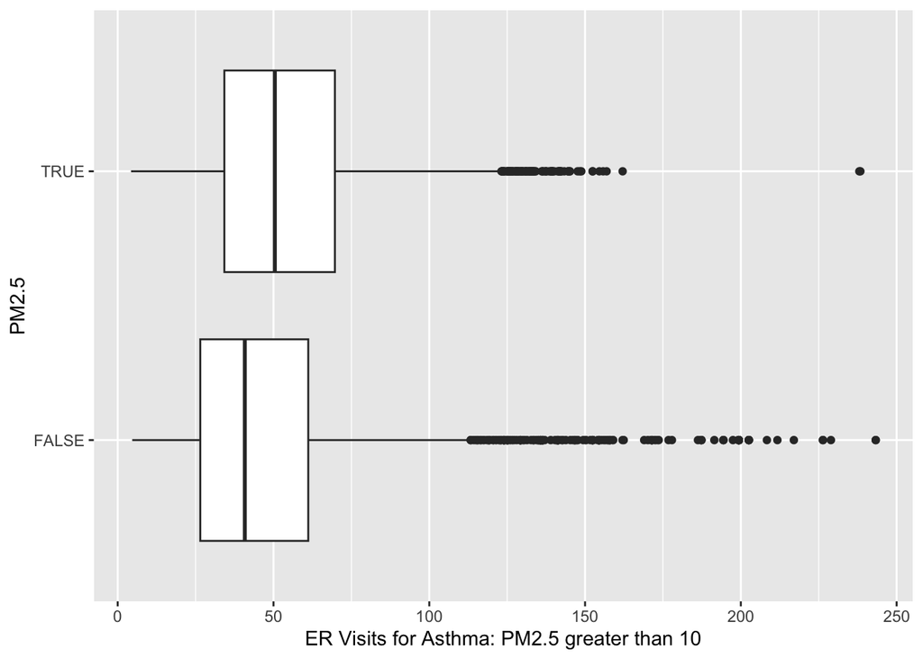

```r
ces_dat <-
  ces |>
  mutate(across(
    starts_with("PM"),
    function(x) x > 10
  ))

ggplot(data = ces_dat, aes(x = Asthma, y = PM2.5)) +
  geom_boxplot() +
  labs(x = "ER Visits for Asthma: PM2.5 greater than 10")
```

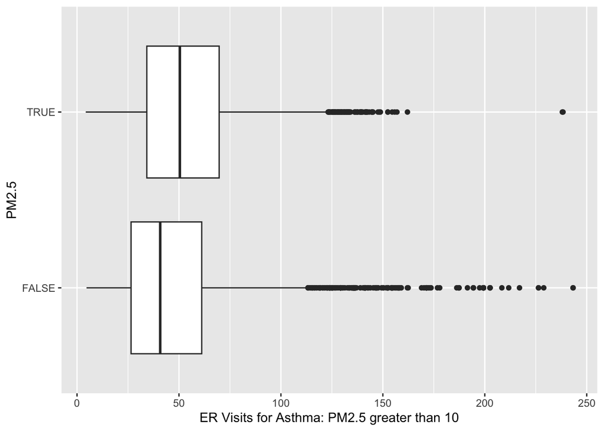

```r
# Make everything a function if you like!
ces_boxplot <- function() {
  ces |>
    mutate(across(
      starts_with("PM"),
      function(x) x > 10
    )) |>
    ggplot(aes(x = Asthma, y = PM2.5)) +
    geom_boxplot() +
    labs(x = "ER Visits for Asthma: PM2.5 greater than 10")
}

ces_boxplot()
```